# Risk Factor Analysis

## Outcome Variable

**Outcome Variable:** ever_stunted

## Predictor Variables

**Intervention Variable:** tr

**Adjustment Set:**

unadjusted

## Stratifying Variables

The analysis was stratified on these variable(s):

- perdiar24
- agecat
- studyid
- country

## Data Summary

| perdiar24 | agecat | studyid | country | tr | ever_stunted | n_cell | n |
| --- | --- | --- | --- | --- | --- | --- | --- |
| Q3 | 0-6 months | ki1000304-Vitamin-B12 | INDIA | Other | 0 | 1 | 1 |
| Q4 | 0-6 months | ki1000304b-SAS-FoodSuppl | INDIA | Control | 0 | 17 | 281 |
| Q4 | 0-6 months | ki1000304b-SAS-FoodSuppl | INDIA | Control | 1 | 10 | 281 |
| Q4 | 0-6 months | ki1000304b-SAS-FoodSuppl | INDIA | Other | 0 | 157 | 281 |
| Q4 | 0-6 months | ki1000304b-SAS-FoodSuppl | INDIA | Other | 1 | 97 | 281 |
| Q1 | 0-6 months | ki1000304b-SAS-FoodSuppl | INDIA | Control | 0 | 46 | 85 |
| Q1 | 0-6 months | ki1000304b-SAS-FoodSuppl | INDIA | Control | 1 | 32 | 85 |
| Q1 | 0-6 months | ki1000304b-SAS-FoodSuppl | INDIA | Other | 0 | 5 | 85 |
| Q1 | 0-6 months | ki1000304b-SAS-FoodSuppl | INDIA | Other | 1 | 2 | 85 |
| Q3 | 0-6 months | ki1000304b-SAS-FoodSuppl | INDIA | Other | 0 | 22 | 37 |
| Q3 | 0-6 months | ki1000304b-SAS-FoodSuppl | INDIA | Other | 1 | 15 | 37 |
| Q2 | 0-6 months | ki1000304b-SAS-FoodSuppl | INDIA | Other | 0 | 10 | 13 |
| Q2 | 0-6 months | ki1000304b-SAS-FoodSuppl | INDIA | Other | 1 | 3 | 13 |
| Q2 | 0-6 months | ki1017093b-PROVIDE | BANGLADESH | Control | 0 | 33 | 165 |
| Q2 | 0-6 months | ki1017093b-PROVIDE | BANGLADESH | Control | 1 | 4 | 165 |
| Q2 | 0-6 months | ki1017093b-PROVIDE | BANGLADESH | Other | 0 | 112 | 165 |
| Q2 | 0-6 months | ki1017093b-PROVIDE | BANGLADESH | Other | 1 | 16 | 165 |
| Q3 | 0-6 months | ki1017093b-PROVIDE | BANGLADESH | Control | 0 | 54 | 254 |
| Q3 | 0-6 months | ki1017093b-PROVIDE | BANGLADESH | Control | 1 | 9 | 254 |
| Q3 | 0-6 months | ki1017093b-PROVIDE | BANGLADESH | Other | 0 | 162 | 254 |
| Q3 | 0-6 months | ki1017093b-PROVIDE | BANGLADESH | Other | 1 | 29 | 254 |
| Q4 | 0-6 months | ki1017093b-PROVIDE | BANGLADESH | Control | 0 | 45 | 171 |
| Q4 | 0-6 months | ki1017093b-PROVIDE | BANGLADESH | Control | 1 | 9 | 171 |
| Q4 | 0-6 months | ki1017093b-PROVIDE | BANGLADESH | Other | 0 | 101 | 171 |
| Q4 | 0-6 months | ki1017093b-PROVIDE | BANGLADESH | Other | 1 | 16 | 171 |
| Q1 | 0-6 months | ki1017093b-PROVIDE | BANGLADESH | Control | 0 | 10 | 50 |
| Q1 | 0-6 months | ki1017093b-PROVIDE | BANGLADESH | Control | 1 | 2 | 50 |
| Q1 | 0-6 months | ki1017093b-PROVIDE | BANGLADESH | Other | 0 | 34 | 50 |
| Q1 | 0-6 months | ki1017093b-PROVIDE | BANGLADESH | Other | 1 | 4 | 50 |
| Q4 | 0-6 months | ki1112895-Guatemala BSC | GUATEMALA | Control | 0 | 59 | 160 |

[output cut: 255 more lines]

The following strata were considered:

- perdiar24: Q1, agecat: 0-24 months, studyid: iLiNS-Zinc_ZvLNS, country: BURKINA FASO
- perdiar24: Q1, agecat: 0-24 months, studyid: ki1000304-Vitamin-B12, country: INDIA
- perdiar24: Q1, agecat: 0-24 months, studyid: ki1000304b-SAS-FoodSuppl, country: INDIA
- perdiar24: Q1, agecat: 0-24 months, studyid: ki1017093b-PROVIDE, country: BANGLADESH
- perdiar24: Q1, agecat: 0-24 months, studyid: ki1112895-Guatemala BSC, country: GUATEMALA
- perdiar24: Q1, agecat: 0-24 months, studyid: ki1112895-iLiNS-Zinc, country: BURKINA FASO
- perdiar24: Q1, agecat: 0-24 months, studyid: kiGH5241-JiVitA-4, country: BANGLADESH
- perdiar24: Q1, agecat: 0-6 months, studyid: ki1000304b-SAS-FoodSuppl, country: INDIA
- perdiar24: Q1, agecat: 0-6 months, studyid: ki1017093b-PROVIDE, country: BANGLADESH
- perdiar24: Q1, agecat: 0-6 months, studyid: ki1112895-Guatemala BSC, country: GUATEMALA
- perdiar24: Q1, agecat: 0-6 months, studyid: kiGH5241-JiVitA-4, country: BANGLADESH
- perdiar24: Q1, agecat: 6-24 months, studyid: iLiNS-Zinc_ZvLNS, country: BURKINA FASO
- perdiar24: Q1, agecat: 6-24 months, studyid: ki1000304-Vitamin-B12, country: INDIA
- perdiar24: Q1, agecat: 6-24 months, studyid: ki1000304b-SAS-FoodSuppl, country: INDIA
- perdiar24: Q1, agecat: 6-24 months, studyid: ki1017093b-PROVIDE, country: BANGLADESH
- perdiar24: Q1, agecat: 6-24 months, studyid: ki1112895-Guatemala BSC, country: GUATEMALA
- perdiar24: Q1, agecat: 6-24 months, studyid: ki1112895-iLiNS-Zinc, country: BURKINA FASO
- perdiar24: Q1, agecat: 6-24 months, studyid: kiGH5241-JiVitA-4, country: BANGLADESH
- perdiar24: Q2, agecat: 0-24 months, studyid: iLiNS-Zinc_ZvLNS, country: BURKINA FASO
- perdiar24: Q2, agecat: 0-24 months, studyid: ki1000304-Vitamin-B12, country: INDIA
- perdiar24: Q2, agecat: 0-24 months, studyid: ki1000304b-SAS-FoodSuppl, country: INDIA
- perdiar24: Q2, agecat: 0-24 months, studyid: ki1017093b-PROVIDE, country: BANGLADESH
- perdiar24: Q2, agecat: 0-24 months, studyid: ki1112895-Guatemala BSC, country: GUATEMALA
- perdiar24: Q2, agecat: 0-24 months, studyid: ki1112895-iLiNS-Zinc, country: BURKINA FASO
- perdiar24: Q2, agecat: 0-24 months, studyid: kiGH5241-JiVitA-4, country: BANGLADESH
- perdiar24: Q2, agecat: 0-6 months, studyid: ki1000304b-SAS-FoodSuppl, country: INDIA
- perdiar24: Q2, agecat: 0-6 months, studyid: ki1017093b-PROVIDE, country: BANGLADESH
- perdiar24: Q2, agecat: 0-6 months, studyid: ki1112895-Guatemala BSC, country: GUATEMALA
- perdiar24: Q2, agecat: 0-6 months, studyid: kiGH5241-JiVitA-4, country: BANGLADESH
- perdiar24: Q2, agecat: 6-24 months, studyid: iLiNS-Zinc_ZvLNS, country: BURKINA FASO
- perdiar24: Q2, agecat: 6-24 months, studyid: ki1000304-Vitamin-B12, country: INDIA
- perdiar24: Q2, agecat: 6-24 months, studyid: ki1000304b-SAS-FoodSuppl, country: INDIA
- perdiar24: Q2, agecat: 6-24 months, studyid: ki1017093b-PROVIDE, country: BANGLADESH
- perdiar24: Q2, agecat: 6-24 months, studyid: ki1112895-Guatemala BSC, country: GUATEMALA
- perdiar24: Q2, agecat: 6-24 months, studyid: ki1112895-iLiNS-Zinc, country: BURKINA FASO
- perdiar24: Q2, agecat: 6-24 months, studyid: kiGH5241-JiVitA-4, country: BANGLADESH
- perdiar24: Q3, agecat: 0-24 months, studyid: iLiNS-Zinc_ZvLNS, country: BURKINA FASO
- perdiar24: Q3, agecat: 0-24 months, studyid: ki1000304-Vitamin-B12, country: INDIA
- perdiar24: Q3, agecat: 0-24 months, studyid: ki1000304b-SAS-FoodSuppl, country: INDIA
- perdiar24: Q3, agecat: 0-24 months, studyid: ki1017093b-PROVIDE, country: BANGLADESH
- perdiar24: Q3, agecat: 0-24 months, studyid: ki1112895-Guatemala BSC, country: GUATEMALA
- perdiar24: Q3, agecat: 0-24 months, studyid: ki1112895-iLiNS-Zinc, country: BURKINA FASO
- perdiar24: Q3, agecat: 0-24 months, studyid: kiGH5241-JiVitA-4, country: BANGLADESH
- perdiar24: Q3, agecat: 0-6 months, studyid: ki1000304-Vitamin-B12, country: INDIA
- perdiar24: Q3, agecat: 0-6 months, studyid: ki1000304b-SAS-FoodSuppl, country: INDIA
- perdiar24: Q3, agecat: 0-6 months, studyid: ki1017093b-PROVIDE, country: BANGLADESH
- perdiar24: Q3, agecat: 0-6 months, studyid: ki1112895-Guatemala BSC, country: GUATEMALA
- perdiar24: Q3, agecat: 0-6 months, studyid: kiGH5241-JiVitA-4, country: BANGLADESH
- perdiar24: Q3, agecat: 6-24 months, studyid: iLiNS-Zinc_ZvLNS, country: BURKINA FASO
- perdiar24: Q3, agecat: 6-24 months, studyid: ki1000304-Vitamin-B12, country: INDIA
- perdiar24: Q3, agecat: 6-24 months, studyid: ki1000304b-SAS-FoodSuppl, country: INDIA
- perdiar24: Q3, agecat: 6-24 months, studyid: ki1017093b-PROVIDE, country: BANGLADESH
- perdiar24: Q3, agecat: 6-24 months, studyid: ki1112895-Guatemala BSC, country: GUATEMALA
- perdiar24: Q3, agecat: 6-24 months, studyid: ki1112895-iLiNS-Zinc, country: BURKINA FASO
- perdiar24: Q3, agecat: 6-24 months, studyid: kiGH5241-JiVitA-4, country: BANGLADESH
- perdiar24: Q4, agecat: 0-24 months, studyid: iLiNS-Zinc_ZvLNS, country: BURKINA FASO
- perdiar24: Q4, agecat: 0-24 months, studyid: ki1000304-Vitamin-B12, country: INDIA
- perdiar24: Q4, agecat: 0-24 months, studyid: ki1000304b-SAS-FoodSuppl, country: INDIA
- perdiar24: Q4, agecat: 0-24 months, studyid: ki1017093b-PROVIDE, country: BANGLADESH
- perdiar24: Q4, agecat: 0-24 months, studyid: ki1112895-Guatemala BSC, country: GUATEMALA
- perdiar24: Q4, agecat: 0-24 months, studyid: ki1112895-iLiNS-Zinc, country: BURKINA FASO
- perdiar24: Q4, agecat: 0-24 months, studyid: kiGH5241-JiVitA-4, country: BANGLADESH
- perdiar24: Q4, agecat: 0-6 months, studyid: ki1000304b-SAS-FoodSuppl, country: INDIA
- perdiar24: Q4, agecat: 0-6 months, studyid: ki1017093b-PROVIDE, country: BANGLADESH
- perdiar24: Q4, agecat: 0-6 months, studyid: ki1112895-Guatemala BSC, country: GUATEMALA
- perdiar24: Q4, agecat: 0-6 months, studyid: kiGH5241-JiVitA-4, country: BANGLADESH
- perdiar24: Q4, agecat: 6-24 months, studyid: iLiNS-Zinc_ZvLNS, country: BURKINA FASO
- perdiar24: Q4, agecat: 6-24 months, studyid: ki1000304-Vitamin-B12, country: INDIA
- perdiar24: Q4, agecat: 6-24 months, studyid: ki1000304b-SAS-FoodSuppl, country: INDIA
- perdiar24: Q4, agecat: 6-24 months, studyid: ki1017093b-PROVIDE, country: BANGLADESH
- perdiar24: Q4, agecat: 6-24 months, studyid: ki1112895-Guatemala BSC, country: GUATEMALA
- perdiar24: Q4, agecat: 6-24 months, studyid: ki1112895-iLiNS-Zinc, country: BURKINA FASO
- perdiar24: Q4, agecat: 6-24 months, studyid: kiGH5241-JiVitA-4, country: BANGLADESH

### Dropped Strata

Some strata were dropped due to rare outcomes:

- perdiar24: Q3, agecat: 0-6 months, studyid: ki1000304-Vitamin-B12, country: INDIA
- perdiar24: Q1, agecat: 0-6 months, studyid: ki1000304b-SAS-FoodSuppl, country: INDIA
- perdiar24: Q2, agecat: 0-6 months, studyid: ki1000304b-SAS-FoodSuppl, country: INDIA
- perdiar24: Q2, agecat: 0-6 months, studyid: ki1017093b-PROVIDE, country: BANGLADESH
- perdiar24: Q1, agecat: 0-6 months, studyid: ki1017093b-PROVIDE, country: BANGLADESH
- perdiar24: Q1, agecat: 0-6 months, studyid: ki1112895-Guatemala BSC, country: GUATEMALA
- perdiar24: Q2, agecat: 0-6 months, studyid: ki1112895-Guatemala BSC, country: GUATEMALA
- perdiar24: Q3, agecat: 0-6 months, studyid: ki1112895-Guatemala BSC, country: GUATEMALA
- perdiar24: Q3, agecat: 6-24 months, studyid: ki1000304-Vitamin-B12, country: INDIA
- perdiar24: Q2, agecat: 6-24 months, studyid: ki1000304-Vitamin-B12, country: INDIA
- perdiar24: Q4, agecat: 6-24 months, studyid: ki1000304-Vitamin-B12, country: INDIA
- perdiar24: Q1, agecat: 6-24 months, studyid: ki1000304-Vitamin-B12, country: INDIA
- perdiar24: Q4, agecat: 6-24 months, studyid: ki1000304b-SAS-FoodSuppl, country: INDIA
- perdiar24: Q1, agecat: 6-24 months, studyid: ki1000304b-SAS-FoodSuppl, country: INDIA
- perdiar24: Q2, agecat: 6-24 months, studyid: ki1017093b-PROVIDE, country: BANGLADESH
- perdiar24: Q1, agecat: 6-24 months, studyid: ki1017093b-PROVIDE, country: BANGLADESH
- perdiar24: Q1, agecat: 6-24 months, studyid: ki1112895-Guatemala BSC, country: GUATEMALA
- perdiar24: Q2, agecat: 6-24 months, studyid: ki1112895-Guatemala BSC, country: GUATEMALA
- perdiar24: Q3, agecat: 6-24 months, studyid: ki1112895-Guatemala BSC, country: GUATEMALA
- perdiar24: Q4, agecat: 0-24 months, studyid: ki1000304b-SAS-FoodSuppl, country: INDIA
- perdiar24: Q1, agecat: 0-24 months, studyid: ki1000304b-SAS-FoodSuppl, country: INDIA
- perdiar24: Q1, agecat: 0-24 months, studyid: ki1112895-Guatemala BSC, country: GUATEMALA
- perdiar24: Q2, agecat: 0-24 months, studyid: ki1112895-Guatemala BSC, country: GUATEMALA

## Methods Detail

We’re interested in the causal parameters $E[Y_a]$ for all values of $a \in \mathcal{A}$. These parameters represent the mean outcome if, possibly contrary to fact, we intervened to set all units to have $A=a$. Under the randomization and positivity assumptions, these are identified by the statistical parameters $\psi_a=E_W[E_{Y|A,W}(Y|A=a,W)]$. In addition, we’re interested in the mean of $Y$, $E[Y]$ under no intervention (the observed mean). We will estimate these parameters by using SuperLearner to fit the relevant likelihood factors – $E_{Y|A,W}(Y|A=a,W)$ and $p(A=a|W)$, and then updating our likelihood fit using a joint TMLE.

For unadjusted analyses ($W=\{\}$), initial likelihoods were estimated using Lrnr_glm to estimate the simple $E(Y|A)$ and Lrnr_mean to estimate $p(A)$. For adjusted analyses, a small library containing Lrnr_glmnet, Lrnr_xgboost, and Lrnr_mean was used.

Having estimated these parameters, we will then use the delta method to estimate relative risks and attributable risks relative to a prespecified baseline level of $A$.

[output not shown]

[output cut: 23 more lines]

[output not shown]

# Results Detail

## Results Plots

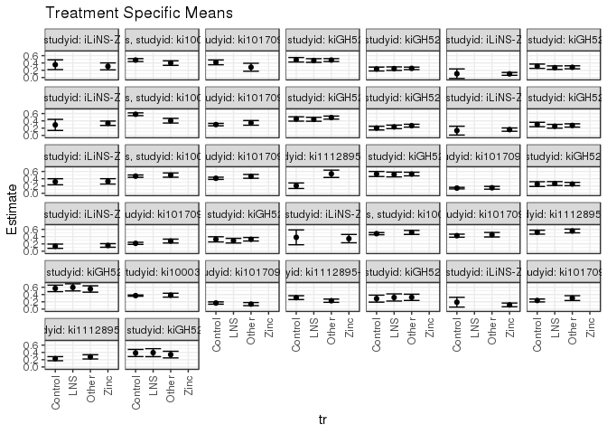

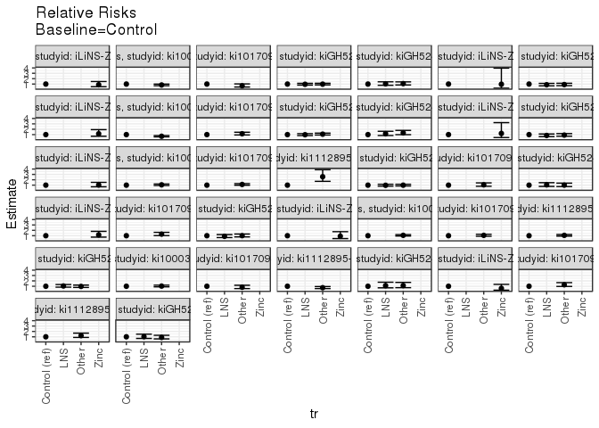

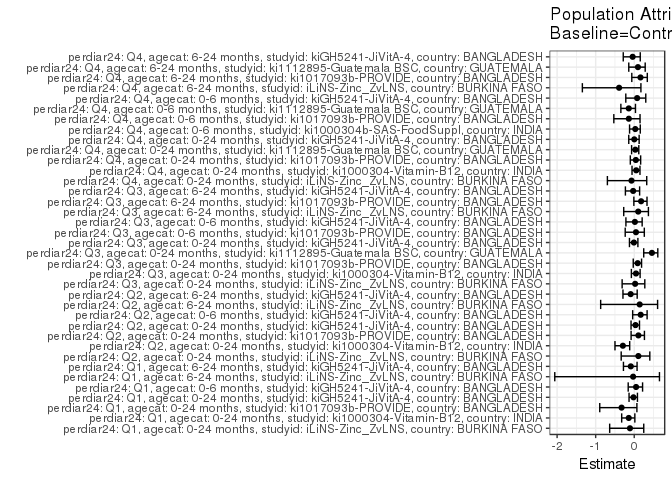

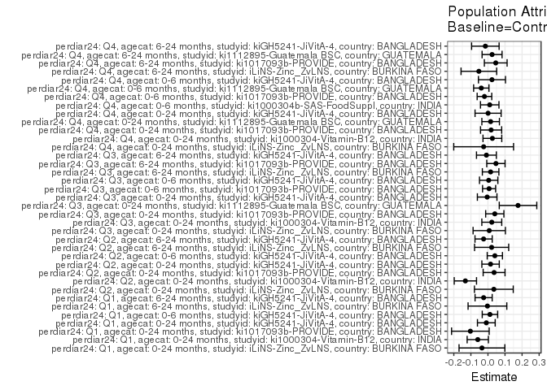

## Results Table

### Parameter: TSM

| perdiar24 | agecat | studyid | country | intervention_level | baseline_level | estimate | ci_lower | ci_upper |
| --- | --- | --- | --- | --- | --- | --- | --- | --- |
| Q1 | 0-24 months | iLiNS-Zinc_ZvLNS | BURKINA FASO | Control | NA | 0.3525180 | 0.2182074 | 0.4868286 |
| Q1 | 0-24 months | iLiNS-Zinc_ZvLNS | BURKINA FASO | Zinc | NA | 0.3064877 | 0.2109807 | 0.4019947 |
| Q1 | 0-24 months | ki1000304-Vitamin-B12 | INDIA | Control | NA | 0.4791667 | 0.4400678 | 0.5182655 |
| Q1 | 0-24 months | ki1000304-Vitamin-B12 | INDIA | Other | NA | 0.3968254 | 0.3347875 | 0.4588633 |
| Q1 | 0-24 months | ki1017093b-PROVIDE | BANGLADESH | Control | NA | 0.4166667 | 0.3503807 | 0.4829526 |
| Q1 | 0-24 months | ki1017093b-PROVIDE | BANGLADESH | Other | NA | 0.2820513 | 0.1729773 | 0.3911252 |
| Q1 | 0-24 months | kiGH5241-JiVitA-4 | BANGLADESH | Control | NA | 0.4875519 | 0.4259667 | 0.5491370 |
| Q1 | 0-24 months | kiGH5241-JiVitA-4 | BANGLADESH | LNS | NA | 0.4677419 | 0.4174489 | 0.5180350 |
| Q1 | 0-24 months | kiGH5241-JiVitA-4 | BANGLADESH | Other | NA | 0.4792123 | 0.4395631 | 0.5188615 |
| Q1 | 0-6 months | kiGH5241-JiVitA-4 | BANGLADESH | Control | NA | 0.2332506 | 0.1801469 | 0.2863543 |
| Q1 | 0-6 months | kiGH5241-JiVitA-4 | BANGLADESH | LNS | NA | 0.2440605 | 0.1963928 | 0.2917282 |
| Q1 | 0-6 months | kiGH5241-JiVitA-4 | BANGLADESH | Other | NA | 0.2515964 | 0.2173457 | 0.2858471 |
| Q1 | 6-24 months | iLiNS-Zinc_ZvLNS | BURKINA FASO | Control | NA | 0.1037736 | -0.0283981 | 0.2359453 |
| Q1 | 6-24 months | iLiNS-Zinc_ZvLNS | BURKINA FASO | Zinc | NA | 0.1000000 | 0.0608145 | 0.1391855 |
| Q1 | 6-24 months | kiGH5241-JiVitA-4 | BANGLADESH | Control | NA | 0.3102564 | 0.2513861 | 0.3691267 |
| Q1 | 6-24 months | kiGH5241-JiVitA-4 | BANGLADESH | LNS | NA | 0.2705100 | 0.2225276 | 0.3184924 |
| Q1 | 6-24 months | kiGH5241-JiVitA-4 | BANGLADESH | Other | NA | 0.2802198 | 0.2389861 | 0.3214535 |
| Q2 | 0-24 months | iLiNS-Zinc_ZvLNS | BURKINA FASO | Control | NA | 0.2887701 | 0.1362859 | 0.4412542 |
| Q2 | 0-24 months | iLiNS-Zinc_ZvLNS | BURKINA FASO | Zinc | NA | 0.3338789 | 0.2736921 | 0.3940657 |
| Q2 | 0-24 months | ki1000304-Vitamin-B12 | INDIA | Control | NA | 0.5813953 | 0.5433144 | 0.6194763 |
| Q2 | 0-24 months | ki1000304-Vitamin-B12 | INDIA | Other | NA | 0.4032258 | 0.3389236 | 0.4675280 |
| Q2 | 0-24 months | ki1017093b-PROVIDE | BANGLADESH | Control | NA | 0.2972973 | 0.2641715 | 0.3304231 |
| Q2 | 0-24 months | ki1017093b-PROVIDE | BANGLADESH | Other | NA | 0.3437500 | 0.2797256 | 0.4077744 |
| Q2 | 0-24 months | kiGH5241-JiVitA-4 | BANGLADESH | Control | NA | 0.4520256 | 0.3919419 | 0.5121092 |
| Q2 | 0-24 months | kiGH5241-JiVitA-4 | BANGLADESH | LNS | NA | 0.4435318 | 0.3890476 | 0.4980160 |
| Q2 | 0-24 months | kiGH5241-JiVitA-4 | BANGLADESH | Other | NA | 0.4894614 | 0.4471184 | 0.5318043 |
| Q2 | 0-6 months | kiGH5241-JiVitA-4 | BANGLADESH | Control | NA | 0.2010444 | 0.1497477 | 0.2523411 |
| Q2 | 0-6 months | kiGH5241-JiVitA-4 | BANGLADESH | LNS | NA | 0.2335766 | 0.1849967 | 0.2821566 |
| Q2 | 0-6 months | kiGH5241-JiVitA-4 | BANGLADESH | Other | NA | 0.2673130 | 0.2285752 | 0.3060508 |
| Q2 | 6-24 months | iLiNS-Zinc_ZvLNS | BURKINA FASO | Control | NA | 0.1312500 | 0.0101966 | 0.2523034 |

[output cut: 56 more lines]

### Parameter: E(Y)

| perdiar24 | agecat | studyid | country | intervention_level | baseline_level | estimate | ci_lower | ci_upper |
| --- | --- | --- | --- | --- | --- | --- | --- | --- |
| Q1 | 0-24 months | iLiNS-Zinc_ZvLNS | BURKINA FASO | NA | NA | 0.3174061 | 0.2433469 | 0.3914654 |
| Q1 | 0-24 months | ki1000304-Vitamin-B12 | INDIA | NA | NA | 0.4195402 | 0.3460046 | 0.4930759 |
| Q1 | 0-24 months | ki1017093b-PROVIDE | BANGLADESH | NA | NA | 0.3137255 | 0.1851119 | 0.4423391 |
| Q1 | 0-24 months | kiGH5241-JiVitA-4 | BANGLADESH | NA | NA | 0.4779939 | 0.4500511 | 0.5059367 |
| Q1 | 0-6 months | kiGH5241-JiVitA-4 | BANGLADESH | NA | NA | 0.2449970 | 0.2202311 | 0.2697629 |
| Q1 | 6-24 months | iLiNS-Zinc_ZvLNS | BURKINA FASO | NA | NA | 0.1008403 | 0.0634113 | 0.1382694 |
| Q1 | 6-24 months | kiGH5241-JiVitA-4 | BANGLADESH | NA | NA | 0.2848948 | 0.2571334 | 0.3126562 |
| Q2 | 0-24 months | iLiNS-Zinc_ZvLNS | BURKINA FASO | NA | NA | 0.3233083 | 0.2579219 | 0.3886946 |
| Q2 | 0-24 months | ki1000304-Vitamin-B12 | INDIA | NA | NA | 0.4491018 | 0.3734356 | 0.5247680 |
| Q2 | 0-24 months | ki1017093b-PROVIDE | BANGLADESH | NA | NA | 0.3333333 | 0.2611861 | 0.4054806 |
| Q2 | 0-24 months | kiGH5241-JiVitA-4 | BANGLADESH | NA | NA | 0.4674033 | 0.4380938 | 0.4967128 |
| Q2 | 0-6 months | kiGH5241-JiVitA-4 | BANGLADESH | NA | NA | 0.2414248 | 0.2152664 | 0.2675832 |
| Q2 | 6-24 months | iLiNS-Zinc_ZvLNS | BURKINA FASO | NA | NA | 0.1528190 | 0.1092255 | 0.1964125 |
| Q2 | 6-24 months | kiGH5241-JiVitA-4 | BANGLADESH | NA | NA | 0.2745367 | 0.2448346 | 0.3042388 |
| Q3 | 0-24 months | iLiNS-Zinc_ZvLNS | BURKINA FASO | NA | NA | 0.3249258 | 0.2719693 | 0.3778824 |
| Q3 | 0-24 months | ki1000304-Vitamin-B12 | INDIA | NA | NA | 0.4930876 | 0.4264146 | 0.5597605 |
| Q3 | 0-24 months | ki1017093b-PROVIDE | BANGLADESH | NA | NA | 0.4527559 | 0.3914206 | 0.5140912 |
| Q3 | 0-24 months | ki1112895-Guatemala BSC | GUATEMALA | NA | NA | 0.3846154 | 0.2510944 | 0.5181364 |
| Q3 | 0-24 months | kiGH5241-JiVitA-4 | BANGLADESH | NA | NA | 0.5260586 | 0.4915809 | 0.5605364 |
| Q3 | 0-6 months | ki1017093b-PROVIDE | BANGLADESH | NA | NA | 0.1496063 | 0.1056549 | 0.1935577 |
| Q3 | 0-6 months | kiGH5241-JiVitA-4 | BANGLADESH | NA | NA | 0.2579403 | 0.2269401 | 0.2889405 |
| Q3 | 6-24 months | iLiNS-Zinc_ZvLNS | BURKINA FASO | NA | NA | 0.1523297 | 0.1085772 | 0.1960823 |
| Q3 | 6-24 months | ki1017093b-PROVIDE | BANGLADESH | NA | NA | 0.2623762 | 0.2015586 | 0.3231939 |
| Q3 | 6-24 months | kiGH5241-JiVitA-4 | BANGLADESH | NA | NA | 0.3167899 | 0.2824028 | 0.3511770 |
| Q4 | 0-24 months | iLiNS-Zinc_ZvLNS | BURKINA FASO | NA | NA | 0.3553299 | 0.2626943 | 0.4479656 |
| Q4 | 0-24 months | ki1000304-Vitamin-B12 | INDIA | NA | NA | 0.5081301 | 0.4455296 | 0.5707306 |
| Q4 | 0-24 months | ki1017093b-PROVIDE | BANGLADESH | NA | NA | 0.4444444 | 0.3697487 | 0.5191402 |
| Q4 | 0-24 months | ki1112895-Guatemala BSC | GUATEMALA | NA | NA | 0.5380117 | 0.4630680 | 0.6129554 |
| Q4 | 0-24 months | kiGH5241-JiVitA-4 | BANGLADESH | NA | NA | 0.5691964 | 0.5158338 | 0.6225590 |
| Q4 | 0-6 months | ki1000304b-SAS-FoodSuppl | INDIA | NA | NA | 0.3807829 | 0.3239069 | 0.4376589 |
| Q4 | 0-6 months | ki1017093b-PROVIDE | BANGLADESH | NA | NA | 0.1461988 | 0.0930891 | 0.1993085 |
| Q4 | 0-6 months | ki1112895-Guatemala BSC | GUATEMALA | NA | NA | 0.2750000 | 0.2055959 | 0.3444041 |
| Q4 | 0-6 months | kiGH5241-JiVitA-4 | BANGLADESH | NA | NA | 0.3104396 | 0.2565886 | 0.3642905 |
| Q4 | 6-24 months | iLiNS-Zinc_ZvLNS | BURKINA FASO | NA | NA | 0.1356467 | 0.0825706 | 0.1887228 |
| Q4 | 6-24 months | ki1017093b-PROVIDE | BANGLADESH | NA | NA | 0.2824427 | 0.2050554 | 0.3598301 |
| Q4 | 6-24 months | ki1112895-Guatemala BSC | GUATEMALA | NA | NA | 0.2522523 | 0.1710914 | 0.3334131 |
| Q4 | 6-24 months | kiGH5241-JiVitA-4 | BANGLADESH | NA | NA | 0.3687316 | 0.3115385 | 0.4259246 |

### Parameter: RR

| perdiar24 | agecat | studyid | country | intervention_level | baseline_level | estimate | ci_lower | ci_upper |
| --- | --- | --- | --- | --- | --- | --- | --- | --- |
| Q1 | 0-24 months | iLiNS-Zinc_ZvLNS | BURKINA FASO | Control | Control | 1.0000000 | 1.0000000 | 1.0000000 |
| Q1 | 0-24 months | iLiNS-Zinc_ZvLNS | BURKINA FASO | Zinc | Control | 0.8694243 | 0.5131188 | 1.4731455 |
| Q1 | 0-24 months | ki1000304-Vitamin-B12 | INDIA | Control | Control | 1.0000000 | 1.0000000 | 1.0000000 |
| Q1 | 0-24 months | ki1000304-Vitamin-B12 | INDIA | Other | Control | 0.8281573 | 0.6942654 | 0.9878710 |
| Q1 | 0-24 months | ki1017093b-PROVIDE | BANGLADESH | Control | Control | 1.0000000 | 1.0000000 | 1.0000000 |
| Q1 | 0-24 months | ki1017093b-PROVIDE | BANGLADESH | Other | Control | 0.6769231 | 0.4455890 | 1.0283576 |
| Q1 | 0-24 months | kiGH5241-JiVitA-4 | BANGLADESH | Control | Control | 1.0000000 | 1.0000000 | 1.0000000 |
| Q1 | 0-24 months | kiGH5241-JiVitA-4 | BANGLADESH | LNS | Control | 0.9593686 | 0.8127509 | 1.1324356 |
| Q1 | 0-24 months | kiGH5241-JiVitA-4 | BANGLADESH | Other | Control | 0.9828949 | 0.8451803 | 1.1430489 |
| Q1 | 0-6 months | kiGH5241-JiVitA-4 | BANGLADESH | Control | Control | 1.0000000 | 1.0000000 | 1.0000000 |
| Q1 | 0-6 months | kiGH5241-JiVitA-4 | BANGLADESH | LNS | Control | 1.0463444 | 0.7752848 | 1.4121734 |
| Q1 | 0-6 months | kiGH5241-JiVitA-4 | BANGLADESH | Other | Control | 1.0786528 | 0.8273275 | 1.4063255 |
| Q1 | 6-24 months | iLiNS-Zinc_ZvLNS | BURKINA FASO | Control | Control | 1.0000000 | 1.0000000 | 1.0000000 |
| Q1 | 6-24 months | iLiNS-Zinc_ZvLNS | BURKINA FASO | Zinc | Control | 0.9636364 | 0.2346334 | 3.9576429 |
| Q1 | 6-24 months | kiGH5241-JiVitA-4 | BANGLADESH | Control | Control | 1.0000000 | 1.0000000 | 1.0000000 |
| Q1 | 6-24 months | kiGH5241-JiVitA-4 | BANGLADESH | LNS | Control | 0.8718917 | 0.6724479 | 1.1304892 |
| Q1 | 6-24 months | kiGH5241-JiVitA-4 | BANGLADESH | Other | Control | 0.9031877 | 0.7104452 | 1.1482209 |
| Q2 | 0-24 months | iLiNS-Zinc_ZvLNS | BURKINA FASO | Control | Control | 1.0000000 | 1.0000000 | 1.0000000 |
| Q2 | 0-24 months | iLiNS-Zinc_ZvLNS | BURKINA FASO | Zinc | Control | 1.1562102 | 0.6961697 | 1.9202532 |
| Q2 | 0-24 months | ki1000304-Vitamin-B12 | INDIA | Control | Control | 1.0000000 | 1.0000000 | 1.0000000 |
| Q2 | 0-24 months | ki1000304-Vitamin-B12 | INDIA | Other | Control | 0.6935484 | 0.5837216 | 0.8240390 |
| Q2 | 0-24 months | ki1017093b-PROVIDE | BANGLADESH | Control | Control | 1.0000000 | 1.0000000 | 1.0000000 |
| Q2 | 0-24 months | ki1017093b-PROVIDE | BANGLADESH | Other | Control | 1.1562500 | 0.9306656 | 1.4365139 |
| Q2 | 0-24 months | kiGH5241-JiVitA-4 | BANGLADESH | Control | Control | 1.0000000 | 1.0000000 | 1.0000000 |
| Q2 | 0-24 months | kiGH5241-JiVitA-4 | BANGLADESH | LNS | Control | 0.9812096 | 0.8187860 | 1.1758533 |
| Q2 | 0-24 months | kiGH5241-JiVitA-4 | BANGLADESH | Other | Control | 1.0828178 | 0.9240081 | 1.2689223 |
| Q2 | 0-6 months | kiGH5241-JiVitA-4 | BANGLADESH | Control | Control | 1.0000000 | 1.0000000 | 1.0000000 |
| Q2 | 0-6 months | kiGH5241-JiVitA-4 | BANGLADESH | LNS | Control | 1.1618163 | 0.8359776 | 1.6146571 |
| Q2 | 0-6 months | kiGH5241-JiVitA-4 | BANGLADESH | Other | Control | 1.3296219 | 0.9915322 | 1.7829923 |
| Q2 | 6-24 months | iLiNS-Zinc_ZvLNS | BURKINA FASO | Control | Control | 1.0000000 | 1.0000000 | 1.0000000 |

[output cut: 56 more lines]

### Parameter: PAR

| perdiar24 | agecat | studyid | country | intervention_level | baseline_level | estimate | ci_lower | ci_upper |
| --- | --- | --- | --- | --- | --- | --- | --- | --- |
| Q1 | 0-24 months | iLiNS-Zinc_ZvLNS | BURKINA FASO | Control | NA | -0.0351118 | -0.1693856 | 0.0991619 |
| Q1 | 0-24 months | ki1000304-Vitamin-B12 | INDIA | Control | NA | -0.0596264 | -0.1219062 | 0.0026534 |
| Q1 | 0-24 months | ki1017093b-PROVIDE | BANGLADESH | Control | NA | -0.1029412 | -0.2131575 | 0.0072751 |
| Q1 | 0-24 months | kiGH5241-JiVitA-4 | BANGLADESH | Control | NA | -0.0095580 | -0.0615424 | 0.0424264 |
| Q1 | 0-6 months | kiGH5241-JiVitA-4 | BANGLADESH | Control | NA | 0.0117463 | -0.0335445 | 0.0570372 |
| Q1 | 6-24 months | iLiNS-Zinc_ZvLNS | BURKINA FASO | Control | NA | -0.0029332 | -0.1164413 | 0.1105748 |
| Q1 | 6-24 months | kiGH5241-JiVitA-4 | BANGLADESH | Control | NA | -0.0253616 | -0.0755259 | 0.0248027 |
| Q2 | 0-24 months | iLiNS-Zinc_ZvLNS | BURKINA FASO | Control | NA | 0.0345382 | -0.0791847 | 0.1482612 |
| Q2 | 0-24 months | ki1000304-Vitamin-B12 | INDIA | Control | NA | -0.1322936 | -0.1976787 | -0.0669084 |
| Q2 | 0-24 months | ki1017093b-PROVIDE | BANGLADESH | Control | NA | 0.0360360 | -0.0280569 | 0.1001290 |
| Q2 | 0-24 months | kiGH5241-JiVitA-4 | BANGLADESH | Control | NA | 0.0153777 | -0.0356435 | 0.0663989 |
| Q2 | 0-6 months | kiGH5241-JiVitA-4 | BANGLADESH | Control | NA | 0.0403804 | -0.0042852 | 0.0850460 |
| Q2 | 6-24 months | iLiNS-Zinc_ZvLNS | BURKINA FASO | Control | NA | 0.0215690 | -0.0784962 | 0.1216342 |
| Q2 | 6-24 months | kiGH5241-JiVitA-4 | BANGLADESH | Control | NA | -0.0254633 | -0.0758997 | 0.0249732 |
| Q3 | 0-24 months | iLiNS-Zinc_ZvLNS | BURKINA FASO | Control | NA | 0.0075605 | -0.0871430 | 0.1022641 |
| Q3 | 0-24 months | ki1000304-Vitamin-B12 | INDIA | Control | NA | 0.0224993 | -0.0358441 | 0.0808427 |
| Q3 | 0-24 months | ki1017093b-PROVIDE | BANGLADESH | Control | NA | 0.0400575 | -0.0133206 | 0.0934355 |
| Q3 | 0-24 months | ki1112895-Guatemala BSC | GUATEMALA | Control | NA | 0.1762821 | 0.0663086 | 0.2862555 |
| Q3 | 0-24 months | kiGH5241-JiVitA-4 | BANGLADESH | Control | NA | -0.0045536 | -0.0619733 | 0.0528661 |
| Q3 | 0-6 months | ki1017093b-PROVIDE | BANGLADESH | Control | NA | 0.0067492 | -0.0315990 | 0.0450973 |
| Q3 | 0-6 months | kiGH5241-JiVitA-4 | BANGLADESH | Control | NA | 0.0043689 | -0.0494828 | 0.0582206 |
| Q3 | 6-24 months | iLiNS-Zinc_ZvLNS | BURKINA FASO | Control | NA | 0.0156391 | -0.0328252 | 0.0641034 |
| Q3 | 6-24 months | ki1017093b-PROVIDE | BANGLADESH | Control | NA | 0.0466900 | -0.0069992 | 0.1003791 |
| Q3 | 6-24 months | kiGH5241-JiVitA-4 | BANGLADESH | Control | NA | -0.0089677 | -0.0671821 | 0.0492467 |
| Q4 | 0-24 months | iLiNS-Zinc_ZvLNS | BURKINA FASO | Control | NA | -0.0252010 | -0.2004564 | 0.1500544 |
| Q4 | 0-24 months | ki1000304-Vitamin-B12 | INDIA | Control | NA | 0.0259872 | -0.0290367 | 0.0810112 |
| Q4 | 0-24 months | ki1017093b-PROVIDE | BANGLADESH | Control | NA | 0.0185185 | -0.0434061 | 0.0804431 |
| Q4 | 0-24 months | ki1112895-Guatemala BSC | GUATEMALA | Control | NA | 0.0157895 | -0.0356805 | 0.0672595 |
| Q4 | 0-24 months | kiGH5241-JiVitA-4 | BANGLADESH | Control | NA | 0.0008511 | -0.0755927 | 0.0772949 |
| Q4 | 0-6 months | ki1000304b-SAS-FoodSuppl | INDIA | Control | NA | 0.0104125 | -0.0436936 | 0.0645187 |
| Q4 | 0-6 months | ki1017093b-PROVIDE | BANGLADESH | Control | NA | -0.0204678 | -0.0632411 | 0.0223054 |
| Q4 | 0-6 months | ki1112895-Guatemala BSC | GUATEMALA | Control | NA | -0.0389535 | -0.0838968 | 0.0059898 |
| Q4 | 0-6 months | kiGH5241-JiVitA-4 | BANGLADESH | Control | NA | 0.0234830 | -0.0557959 | 0.1027619 |
| Q4 | 6-24 months | iLiNS-Zinc_ZvLNS | BURKINA FASO | Control | NA | -0.0532422 | -0.1576546 | 0.0511702 |
| Q4 | 6-24 months | ki1017093b-PROVIDE | BANGLADESH | Control | NA | 0.0456006 | -0.0210289 | 0.1122301 |
| Q4 | 6-24 months | ki1112895-Guatemala BSC | GUATEMALA | Control | NA | 0.0241821 | -0.0343832 | 0.0827474 |
| Q4 | 6-24 months | kiGH5241-JiVitA-4 | BANGLADESH | Control | NA | -0.0151970 | -0.0957754 | 0.0653814 |

### Parameter: PAF

| perdiar24 | agecat | studyid | country | intervention_level | baseline_level | estimate | ci_lower | ci_upper |
| --- | --- | --- | --- | --- | --- | --- | --- | --- |
| Q1 | 0-24 months | iLiNS-Zinc_ZvLNS | BURKINA FASO | Control | NA | -0.1106212 | -0.6369910 | 0.2464959 |
| Q1 | 0-24 months | ki1000304-Vitamin-B12 | INDIA | Control | NA | -0.1421233 | -0.3254991 | 0.0158835 |
| Q1 | 0-24 months | ki1017093b-PROVIDE | BANGLADESH | Control | NA | -0.3281250 | -0.8944709 | 0.0689136 |
| Q1 | 0-24 months | kiGH5241-JiVitA-4 | BANGLADESH | Control | NA | -0.0199961 | -0.1346295 | 0.0830557 |
| Q1 | 0-6 months | kiGH5241-JiVitA-4 | BANGLADESH | Control | NA | 0.0479449 | -0.1565702 | 0.2162958 |
| Q1 | 6-24 months | iLiNS-Zinc_ZvLNS | BURKINA FASO | Control | NA | -0.0290880 | -2.0605352 | 0.6539748 |
| Q1 | 6-24 months | kiGH5241-JiVitA-4 | BANGLADESH | Control | NA | -0.0890208 | -0.2797321 | 0.0732699 |
| Q2 | 0-24 months | iLiNS-Zinc_ZvLNS | BURKINA FASO | Control | NA | 0.1068275 | -0.3381347 | 0.4038290 |
| Q2 | 0-24 months | ki1000304-Vitamin-B12 | INDIA | Control | NA | -0.2945736 | -0.4993704 | -0.1177498 |
| Q2 | 0-24 months | ki1017093b-PROVIDE | BANGLADESH | Control | NA | 0.1081081 | -0.0813881 | 0.2643981 |
| Q2 | 0-24 months | kiGH5241-JiVitA-4 | BANGLADESH | Control | NA | 0.0329003 | -0.0827934 | 0.1362325 |
| Q2 | 0-6 months | kiGH5241-JiVitA-4 | BANGLADESH | Control | NA | 0.1672588 | -0.0405549 | 0.3335691 |
| Q2 | 6-24 months | iLiNS-Zinc_ZvLNS | BURKINA FASO | Control | NA | 0.1411408 | -0.8705829 | 0.6056635 |
| Q2 | 6-24 months | kiGH5241-JiVitA-4 | BANGLADESH | Control | NA | -0.0927500 | -0.2925088 | 0.0761358 |
| Q3 | 0-24 months | iLiNS-Zinc_ZvLNS | BURKINA FASO | Control | NA | 0.0232685 | -0.3138889 | 0.2739079 |
| Q3 | 0-24 months | ki1000304-Vitamin-B12 | INDIA | Control | NA | 0.0456295 | -0.0742908 | 0.1521634 |
| Q3 | 0-24 months | ki1017093b-PROVIDE | BANGLADESH | Control | NA | 0.0884748 | -0.0257639 | 0.1899908 |
| Q3 | 0-24 months | ki1112895-Guatemala BSC | GUATEMALA | Control | NA | 0.4583333 | 0.2458659 | 0.6109408 |
| Q3 | 0-24 months | kiGH5241-JiVitA-4 | BANGLADESH | Control | NA | -0.0086561 | -0.1238820 | 0.0947563 |
| Q3 | 0-6 months | ki1017093b-PROVIDE | BANGLADESH | Control | NA | 0.0451128 | -0.2339924 | 0.2610898 |
| Q3 | 0-6 months | kiGH5241-JiVitA-4 | BANGLADESH | Control | NA | 0.0169376 | -0.2159381 | 0.2052131 |
| Q3 | 6-24 months | iLiNS-Zinc_ZvLNS | BURKINA FASO | Control | NA | 0.1026661 | -0.2727403 | 0.3673429 |
| Q3 | 6-24 months | ki1017093b-PROVIDE | BANGLADESH | Control | NA | 0.1779504 | -0.0100756 | 0.3309753 |
| Q3 | 6-24 months | kiGH5241-JiVitA-4 | BANGLADESH | Control | NA | -0.0283081 | -0.2291453 | 0.1397131 |
| Q4 | 0-24 months | iLiNS-Zinc_ZvLNS | BURKINA FASO | Control | NA | -0.0709229 | -0.6960656 | 0.3238022 |
| Q4 | 0-24 months | ki1000304-Vitamin-B12 | INDIA | Control | NA | 0.0511429 | -0.0574246 | 0.1485635 |
| Q4 | 0-24 months | ki1017093b-PROVIDE | BANGLADESH | Control | NA | 0.0416667 | -0.1016738 | 0.1663569 |
| Q4 | 0-24 months | ki1112895-Guatemala BSC | GUATEMALA | Control | NA | 0.0293478 | -0.0681508 | 0.1179470 |
| Q4 | 0-24 months | kiGH5241-JiVitA-4 | BANGLADESH | Control | NA | 0.0014953 | -0.1422420 | 0.1271450 |
| Q4 | 0-6 months | ki1000304b-SAS-FoodSuppl | INDIA | Control | NA | 0.0273451 | -0.1211689 | 0.1561864 |
| Q4 | 0-6 months | ki1017093b-PROVIDE | BANGLADESH | Control | NA | -0.1400000 | -0.5292695 | 0.1501825 |
| Q4 | 0-6 months | ki1112895-Guatemala BSC | GUATEMALA | Control | NA | -0.1416490 | -0.3466723 | 0.0321606 |
| Q4 | 0-6 months | kiGH5241-JiVitA-4 | BANGLADESH | Control | NA | 0.0756445 | -0.2188449 | 0.2989813 |
| Q4 | 6-24 months | iLiNS-Zinc_ZvLNS | BURKINA FASO | Control | NA | -0.3925065 | -1.3450736 | 0.1731286 |
| Q4 | 6-24 months | ki1017093b-PROVIDE | BANGLADESH | Control | NA | 0.1614509 | -0.0632639 | 0.3386735 |
| Q4 | 6-24 months | ki1112895-Guatemala BSC | GUATEMALA | Control | NA | 0.0958647 | -0.1417835 | 0.2840493 |
| Q4 | 6-24 months | kiGH5241-JiVitA-4 | BANGLADESH | Control | NA | -0.0412143 | -0.2846594 | 0.1560976 |